# panel_analysis

Jinwen Wu

2025-09-25

## Setup

```r
set.seed(12345)
required_packages <- c(
  "tidyverse", "panelView", "countrycode", "janitor", "fixest", "modelsummary", "haven", "ggplot2", "fect", "haven")

# Get a list of packages that are not yet installed
new_packages <- required_packages[!sapply(required_packages, requireNamespace, quietly = TRUE)]

# Install any missing packages silently
if (length(new_packages) > 0) {
  install.packages(new_packages, quiet = TRUE)
}

invisible(suppressPackageStartupMessages(
  lapply(required_packages, library, character.only = TRUE)
))
```

```r
merged_use_panel <- read.csv("../output/data/panel.csv")
```

# Review the Dataset

```r
names(merged_use_panel)
```

```
##  [1] "iso3"             "year"             "banking_crisis"   "systemic_crisis"
##  [5] "gold_standard"    "domestic_default" "independence"     "currency_crisis"
##  [9] "inflation_crisis" "external_default" "any_crisis"       "is_inter"
## [13] "is_intra"         "homeland"         "at_war"           "flag_RR"
## [17] "flag_GCD"         "n_war"            "milex"            "milper"
## [21] "irst"             "pec"              "tpop"             "upop"
## [25] "upopgrowth"       "cinc"
```

```r
grab_ci <- function(model, vars) {
  ct <- fixest::coeftable(model)
  out <- tibble(
    variable  = rownames(ct),
    estimate  = ct[, 1],
    std.error = ct[, 2]
  ) %>%
    filter(variable %in% vars) %>%
    mutate(
      lb = estimate - 1.96 * std.error,
      ub = estimate + 1.96 * std.error,
      model = deparse(substitute(model))
    )
  out
}

collect_est <- function(mod) {
  est <- mod$est.avg
  est.out <- matrix(NA, nrow=1, ncol=7)
  est.out[1,1:7] <- est[1:7]
  colnames(est.out) <- c("estimate","se","lb","ub","se.boot","lb.boot","ub.boot")
  return(est.out)
}

make_panel_single <- function(df, facet_title,
                              ylab = NULL, xlab = NULL,
                              ylim_all = NULL,
                              show_ylim = TRUE) {
  df <- df %>% mutate(type = facet_title)

  p <- ggplot(df, aes(x = x_lab, y = estimate,
                      colour = ifelse(lb < 0 & ub > 0, "red", "black"))) +
    geom_hline(yintercept = 0, linetype = "dashed",
               colour = "grey60", linewidth = 0.9) +
    geom_errorbar(aes(ymin = lb, ymax = ub),
                  width = 0.2, linewidth = 0.9, show.legend = FALSE) +
    geom_point(size = 2) +
    scale_colour_identity() +
    facet_wrap(~type) +
    labs(x = xlab, y = ylab) +
    theme_bw() +
    theme(
      strip.background = element_rect(fill = "grey90", colour = "black"),
      strip.text       = element_text(size = 11, face = "bold"),
      axis.text.x      = element_text(size = 10,  hjust = 0.5),
      axis.title.x     = element_text(size = 11),
      axis.title.y     = element_text(size = 12)
    )

  if (show_ylim && !is.null(ylim_all)) {
    p <- p +
      scale_y_continuous(limits = ylim_all,
                         expand = expansion(mult = 0),
                         oob = scales::oob_keep)
  } else if (!show_ylim) {
    p <- p +
      scale_y_continuous(limits = ylim_all,
                         breaks = NULL, labels = NULL,
                         expand = expansion(mult = 0),
                         oob = scales::oob_keep) +
      theme(axis.text.y  = element_blank(),
            axis.ticks.y = element_blank(),
            axis.title.y = element_blank())
  }

  p
}
```

## FEct

### Effect of War on State Capacity

```r
# Use IFEct to review analyze the effect of war on state capacity
ife_base <- fect(cinc ~ at_war, data = merged_use_panel,
               index = c("iso3","year"), force = "two-way", method = "ife", r = c(0,5),
               se = TRUE, cores = 8, nboots = 10, parallel = TRUE)
```

```
## For identification purposes, units whose number of untreated periods <5 are dropped automatically.
```

```
## Parallel computing ...
```

```
## Cross-validating ...
```

```
## Criterion: Mean Squared Prediction Error
```

```
## Interactive fixed effects model...
```

```
## r = 0; sigma2 = 0.00027; IC = -7.76457; PC = 0.00025; MSPE = 0.00028
```

```
## r = 1; sigma2 = 0.00002; IC = -9.93288; PC = 0.00002; MSPE = 0.00004
```

```
## r = 2; sigma2 = 0.00001; IC = -10.60824; PC = 0.00001; MSPE = 0.00004
```

```
## r = 3; sigma2 = 0.00000; IC = -10.62264; PC = 0.00001; MSPE = 0.00007
```

```
## r = 4; sigma2 = 0.00000; IC = -10.65667; PC = 0.00000; MSPE = 0.00021
```

```
## r = 5; sigma2 = 0.00000; IC = -10.54202; PC = 0.00000; MSPE = 0.00024
```

```
##
##  r* = 1
```

```
## F-test Failed. The estimated covariance matrix is singular.
```

```r
# Base, use the original cinc but control for military capacity
ife_remove_mil <- fect(cinc ~ at_war + milex + milper, data = merged_use_panel, index = c("iso3","year"), force = "two-way", method = "ife", r = c(0,5), se = TRUE, cores = 8, nboots = 10, parallel = TRUE)
```

```
## For identification purposes, units whose number of untreated periods <5 are dropped automatically.
```

```
## Parallel computing ...
```

```
## Cross-validating ...
```

```
## Criterion: Mean Squared Prediction Error
```

```
## Interactive fixed effects model...
```

```
## r = 0; sigma2 = 0.00025; IC = -7.84468; PC = 0.00023; MSPE = 0.00033
```

```
## r = 1; sigma2 = 0.00002; IC = -10.17474; PC = 0.00002; MSPE = 0.00004
```

```
## r = 2; sigma2 = 0.00001; IC = -10.45688; PC = 0.00001; MSPE = 0.00004
```

```
## r = 3; sigma2 = 0.00000; IC = -10.66596; PC = 0.00001; MSPE = 0.00010
```

```
## r = 4; sigma2 = 0.00000; IC = -10.76922; PC = 0.00000; MSPE = 0.00017
```

```
## r = 5; sigma2 = 0.00000; IC = -10.50916; PC = 0.00000; MSPE = 0.00023
```

```
##
##  r* = 1
```

```
## F-test Failed. The estimated covariance matrix is singular.
```

```r
ife_base
```

```
## Call:
## fect.formula(formula = cinc ~ at_war, data = merged_use_panel,
##     index = c("iso3", "year"), force = "two-way", r = c(0, 5),
##     method = "ife", se = TRUE, nboots = 10, parallel = TRUE,
##     cores = 8)
##
## ATT:
##                                ATT     S.E. CI.lower CI.upper  p.value
## Tr obs equally weighted   0.006709 0.002382 0.002039  0.01138 0.004865
## Tr units equally weighted       NA 0.002431       NA       NA       NA
```

```r
ife_remove_mil
```

```
## Call:
## fect.formula(formula = cinc ~ at_war + milex + milper, data = merged_use_panel,
##     index = c("iso3", "year"), force = "two-way", r = c(0, 5),
##     method = "ife", se = TRUE, nboots = 10, parallel = TRUE,
##     cores = 8)
##
## ATT:
##                                ATT     S.E. CI.lower CI.upper p.value
## Tr obs equally weighted   0.005412 0.004261 -0.00294  0.01376  0.2041
## Tr units equally weighted       NA 0.007572       NA       NA      NA
##
## Covariates:
##             Coef      S.E.   CI.lower  CI.upper p.value
## milex  5.332e-07 7.305e-07 -8.987e-07 1.965e-06  0.4655
## milper 5.908e-06 7.041e-05 -1.321e-04 1.439e-04  0.9331
```

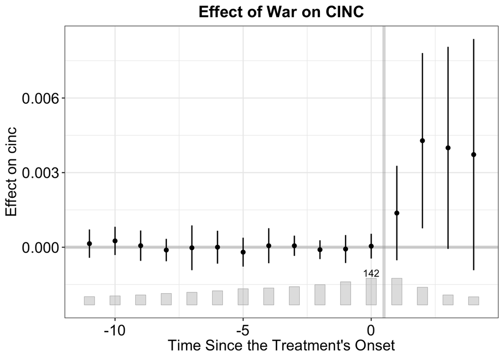

```r
plot(ife_base, main = "Effect of War on CINC")
```

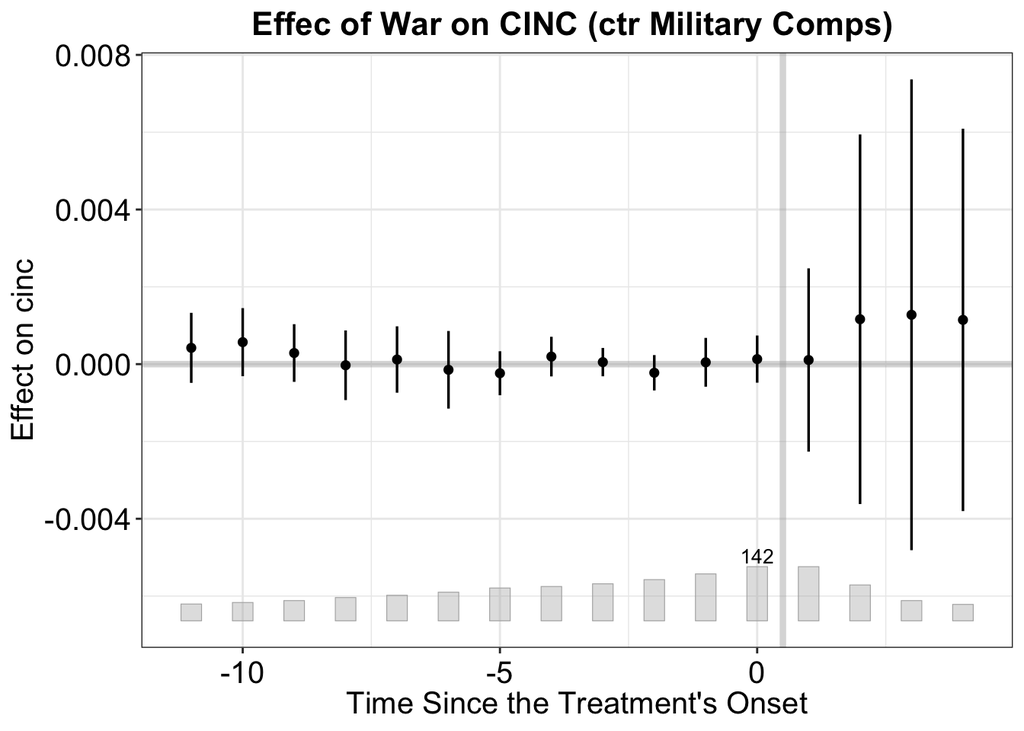

```r
plot(ife_remove_mil, main = "Effec of War on CINC (ctr Military Comps) ")
```

```r
placebo_ife_base <- fect(cinc ~ at_war, data = merged_use_panel,
                    index = c("iso3","year"), force = "two-way", method = "ife",
                    placeboTest = TRUE, placebo.period = c(-2,0), se = 1)
```

```
## For identification purposes, units whose number of untreated periods <5 are dropped automatically.
```

```
## Parallel computing ...
```

```r
carryover_ife_base <- fect(cinc ~ at_war, data = merged_use_panel,
                     index = c("iso3","year"), force = "two-way", method = "ife",
                     carryoverTest = TRUE, carryover.period = c(1,5), se = 1)
```

```
## For identification purposes, units whose number of untreated periods <5 are dropped automatically.
##
## Parallel computing ...
```

```r
ife_test <- rbind(
  round(ife_base$test.out$f.p, 3),
  round(ife_base$test.out$tost.equiv.p, 3),
  round(placebo_ife_base$test.out$placebo.p, 3),
  round(carryover_ife_base$test.out$carryover.p, 3)
)
rownames(ife_test) <- c("F test","Equivalence test","Placebo test","Carryover test")
colnames(ife_test) <- "p-value"

ife_test
```

```
##                  p-value
## F test                NA
## Equivalence test   0.000
## Placebo test       0.327
## Carryover test     0.304
```

✅ What the Final Warning Means

“F-test Failed. The estimated covariance matrix is singular.”

This means:

When testing whether adding more latent factors significantly improves model fit, the statistical test could not be computed.

The covariance matrix was singular — likely because there is insufficient variation or too many fixed effects relative to observations, or the added factors are collinear.

### Interstate

```r
# The new cinc index that does not accounting for military features
ife_cinc_war_1 <- fect(cinc ~ at_war + is_inter + homeland + tpop, data = merged_use_panel, index = c("iso3","year"), force = "unit", method = "ife", r = c(0,5), se = TRUE, cores = 16, nboots = 10, parallel = TRUE)
```

```
## For identification purposes, units whose number of untreated periods <5 are dropped automatically.
```

```
## Parallel computing ...
```

```
## The variables 'x.1' and 'x.2' have been removed because of collinearity (see
## $collin.var).
```

```
## Cross-validating ...
```

```
## Criterion: Mean Squared Prediction Error
```

[output not shown]

```
## Interactive fixed effects model...
```

```
## r = 0; sigma2 = 0.00022; IC = -8.26451; PC = 0.00021; MSPE = 0.00035
```

```
## r = 1; sigma2 = 0.00003; IC = -9.88015; PC = 0.00003; MSPE = 0.00003
```

```
## r = 2; sigma2 = 0.00001; IC = -10.91360; PC = 0.00001; MSPE = 0.00019
```

```
## r = 3; sigma2 = 0.00000; IC = -10.96131; PC = 0.00001; MSPE = 0.00026
```

```
## r = 4; sigma2 = 0.00000; IC = -10.92592; PC = 0.00000; MSPE = 0.00022
```

```
## r = 5; sigma2 = 0.00000; IC = -10.74104; PC = 0.00000; MSPE = 0.00024
```

```
##
##  r* = 1
```

```
## F-test Failed. The estimated covariance matrix is singular.
```

```r
ife_cinc_war_2 <- fect(cinc ~ at_war + is_inter + homeland + pec + irst + tpop + upop, data = merged_use_panel, index = c("iso3","year"), force = "unit", method = "ife", se = TRUE, cores = 16, nboots = 100, parallel = TRUE)
```

```
## For identification purposes, units whose number of untreated periods <5 are dropped automatically.
```

```
## Parallel computing ...
```

```
## The variables 'x.1' and 'x.2' have been removed because of collinearity (see
## $collin.var).
```

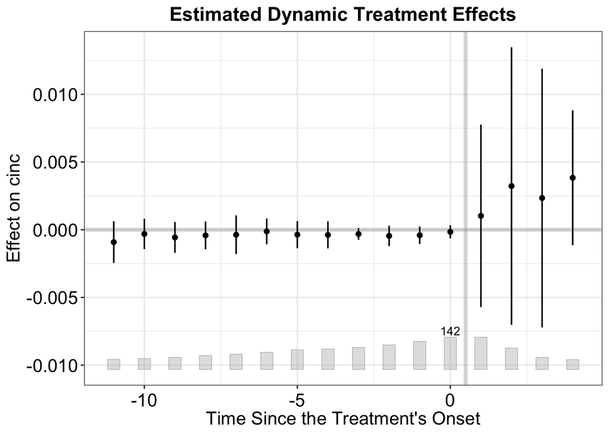

```r
plot(ife_cinc_war_1)
```

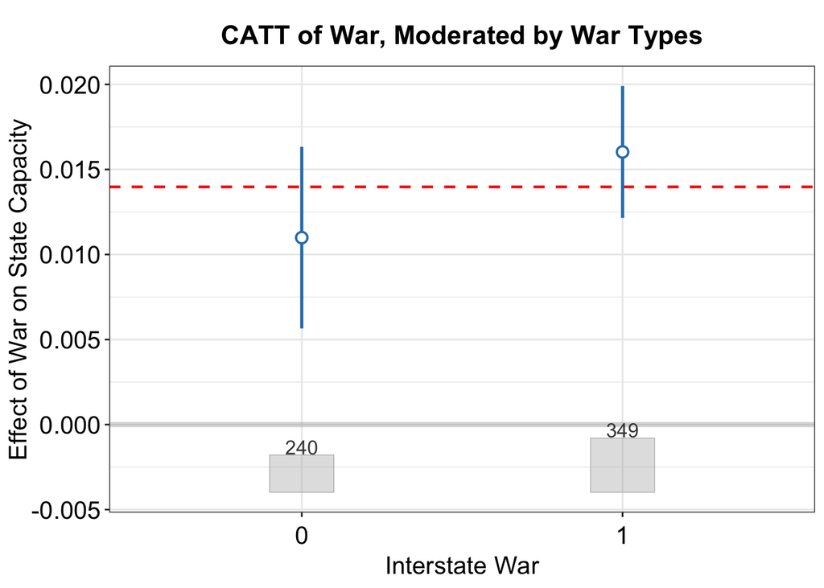

```r
plot(ife_cinc_war_1, type = "hte", covariate="is_inter", main = "CATT of War, Moderated by War Types", xlab = "Interstate War", ylab = "Effect of War on State Capacity")
```

```r
ife_cinc_war_1
```

```
## Call:
## fect.formula(formula = cinc ~ at_war + is_inter + homeland +
##     tpop, data = merged_use_panel, index = c("iso3", "year"),
##     force = "unit", r = c(0, 5), method = "ife", se = TRUE, nboots = 10,
##     parallel = TRUE, cores = 16)
##
## ATT:
##                               ATT     S.E.   CI.lower CI.upper p.value
## Tr obs equally weighted   0.01398 0.007468 -0.0006619  0.02861  0.0613
## Tr units equally weighted      NA 0.003360         NA       NA      NA
##
## Covariates:
##                Coef      S.E.   CI.lower  CI.upper p.value
## is_inter -2.117e-04 3.843e-03 -7.744e-03 7.321e-03  0.9561
## homeland -2.178e-04 1.405e-03 -2.972e-03 2.536e-03  0.8768
## tpop      6.342e-09 1.446e-07 -2.770e-07 2.897e-07  0.9650
```

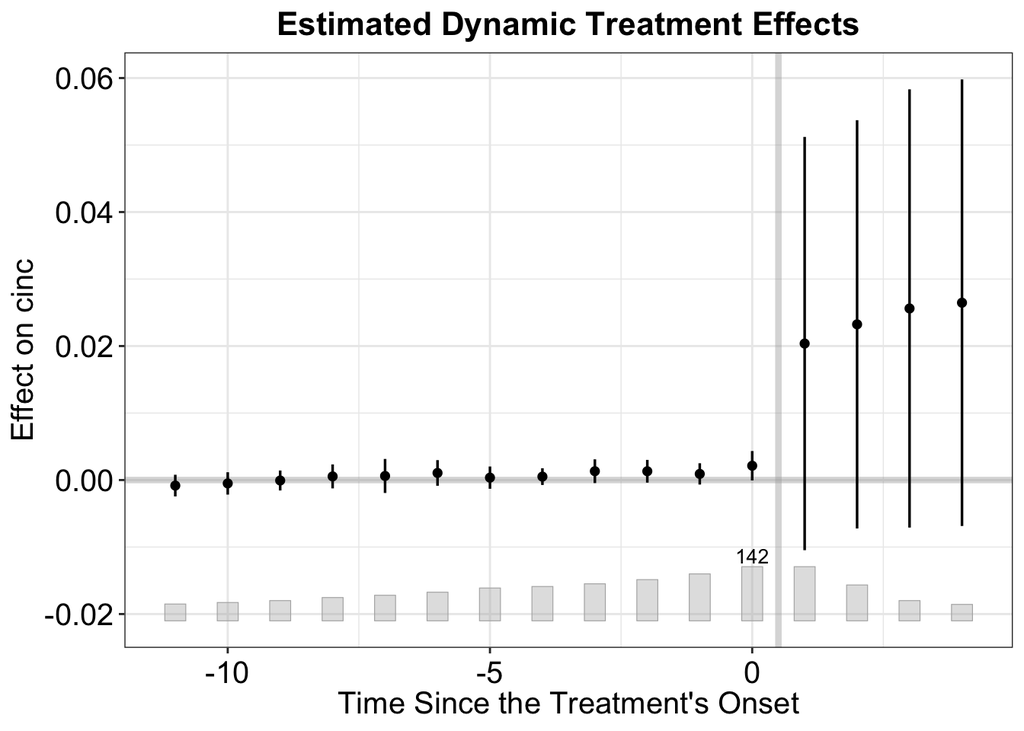

```r
plot(ife_cinc_war_2 )
```

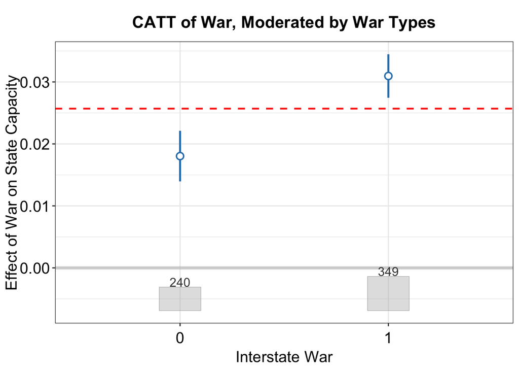

```r
plot(ife_cinc_war_2 , type = "hte", covariate="is_inter", main = "CATT of War, Moderated by War Types", xlab = "Interstate War", ylab = "Effect of War on State Capacity")
```

```r
ife_cinc_war_2
```

```
## Call:
## fect.formula(formula = cinc ~ at_war + is_inter + homeland +
##     pec + irst + tpop + upop, data = merged_use_panel, index = c("iso3",
##     "year"), force = "unit", method = "ife", se = TRUE, nboots = 100,
##     parallel = TRUE, cores = 16)
##
## ATT:
##                               ATT    S.E.  CI.lower CI.upper p.value
## Tr obs equally weighted   0.02569 0.01575 -0.005182  0.05656 0.10290
## Tr units equally weighted 0.02673 0.01546 -0.003574  0.05704 0.08383
##
## Covariates:
##                Coef      S.E.   CI.lower  CI.upper p.value
## is_inter -1.183e-02 1.691e-02 -4.498e-02 2.131e-02  0.4841
## homeland -1.845e-02 1.704e-02 -5.185e-02 1.495e-02  0.2789
## pec       1.009e-07 7.011e-07 -1.273e-06 1.475e-06  0.8855
## irst      8.342e-06 7.379e-06 -6.120e-06 2.280e-05  0.2583
## tpop      5.305e-07 8.080e-07 -1.053e-06 2.114e-06  0.5114
## upop     -7.519e-06 6.866e-06 -2.098e-05 5.939e-06  0.2735
```

### Homeland Credit Constraints

```r
# The new cinc index that does not accounting for military features
ife_cinc_war_homeland_1 <- fect(cinc ~ at_war + homeland + tpop, data = merged_use_panel, index = c("iso3","year"), force = "unit", method = "ife", r = c(0,5), se = TRUE, cores = 16, nboots = 10, parallel = TRUE)
```

```
## For identification purposes, units whose number of untreated periods <5 are dropped automatically.
```

```
## Parallel computing ...
```

```
## The variable 'x.1' has been removed because of collinearity (see $collin.var).
```

```
## Cross-validating ...
```

```
## Criterion: Mean Squared Prediction Error
```

[output not shown]

```
## Interactive fixed effects model...
```

```
## r = 0; sigma2 = 0.00022; IC = -8.26686; PC = 0.00021; MSPE = 0.00031
```

```
## r = 1; sigma2 = 0.00003; IC = -9.88366; PC = 0.00003; MSPE = 0.00003
```

```
## r = 2; sigma2 = 0.00001; IC = -10.91669; PC = 0.00001; MSPE = 0.00012
```

```
## r = 3; sigma2 = 0.00000; IC = -10.96488; PC = 0.00001; MSPE = 0.00020
```

```
## r = 4; sigma2 = 0.00000; IC = -10.92944; PC = 0.00000; MSPE = 0.00016
```

```
## r = 5; sigma2 = 0.00000; IC = -10.74468; PC = 0.00000; MSPE = 0.00019
```

```
##
##  r* = 1
```

```
## F-test Failed. The estimated covariance matrix is singular.
```

```r
ife_cinc_war_homeland_2 <- fect(cinc ~ at_war + homeland + pec + irst + tpop + upop, data = merged_use_panel, index = c("iso3","year"), force = "unit", method = "ife", se = TRUE, cores = 16, nboots = 100, parallel = TRUE)
```

```
## For identification purposes, units whose number of untreated periods <5 are dropped automatically.
```

```
## Parallel computing ...
```

```
## The variable 'x.1' has been removed because of collinearity (see $collin.var).
```

## Econ Features

### Domestic

```r
ife_cinc_dom_economy_1 <- fect(cinc ~ at_war + any_crisis + tpop, data = merged_use_panel,
               index = c("iso3","year"), force = "two-way", method = "ife", r = c(0,5),
               se = TRUE, cores = 8, nboots = 10, parallel = TRUE)
```

```
## For identification purposes, units whose number of untreated periods <5 are dropped automatically.
```

```
## Parallel computing ...
```

```
## Cross-validating ...
```

```
## Criterion: Mean Squared Prediction Error
```

```
## Interactive fixed effects model...
```

```
## r = 0; sigma2 = 0.00020; IC = -8.04890; PC = 0.00019; MSPE = 0.00028
```

```
## r = 1; sigma2 = 0.00001; IC = -10.40412; PC = 0.00001; MSPE = 0.00002
```

```
## r = 2; sigma2 = 0.00001; IC = -10.41272; PC = 0.00001; MSPE = 0.00005
```

```
## r = 3; sigma2 = 0.00001; IC = -10.34681; PC = 0.00001; MSPE = 0.00014
```

```
## r = 4; sigma2 = 0.00000; IC = -10.39883; PC = 0.00001; MSPE = 0.00015
```

```
## r = 5; sigma2 = 0.00000; IC = -10.19587; PC = 0.00001; MSPE = 0.00018
```

```
##
##  r* = 1
```

```
## F-test Failed. The estimated covariance matrix is singular.
```

```r
ife_cinc_dom_economy_2 <- fect(cinc ~ at_war + any_crisis + tpop + milex + milper, data = merged_use_panel,
               index = c("iso3","year"), force = "two-way", method = "ife", r = c(0,5),
               se = TRUE, cores = 8, nboots = 10, parallel = TRUE)
```

```
## For identification purposes, units whose number of untreated periods <5 are dropped automatically.
```

```
## Parallel computing ...
```

```
## Cross-validating ...
```

```
## Criterion: Mean Squared Prediction Error
```

```
## Interactive fixed effects model...
```

```
## r = 0; sigma2 = 0.00020; IC = -8.07175; PC = 0.00018; MSPE = 0.00021
```

```
## r = 1; sigma2 = 0.00001; IC = -10.46997; PC = 0.00001; MSPE = 0.00003
```

```
## r = 2; sigma2 = 0.00001; IC = -10.48715; PC = 0.00001; MSPE = 0.00003
```

```
## r = 3; sigma2 = 0.00001; IC = -10.20478; PC = 0.00001; MSPE = 0.00008
```

```
## r = 4; sigma2 = 0.00000; IC = -10.18046; PC = 0.00001; MSPE = 0.00007
```

```
## r = 5; sigma2 = 0.00000; IC = -9.84674; PC = 0.00001; MSPE = 0.00013
```

```
##
##  r* = 1
```

```
## F-test Failed. The estimated covariance matrix is singular.
```

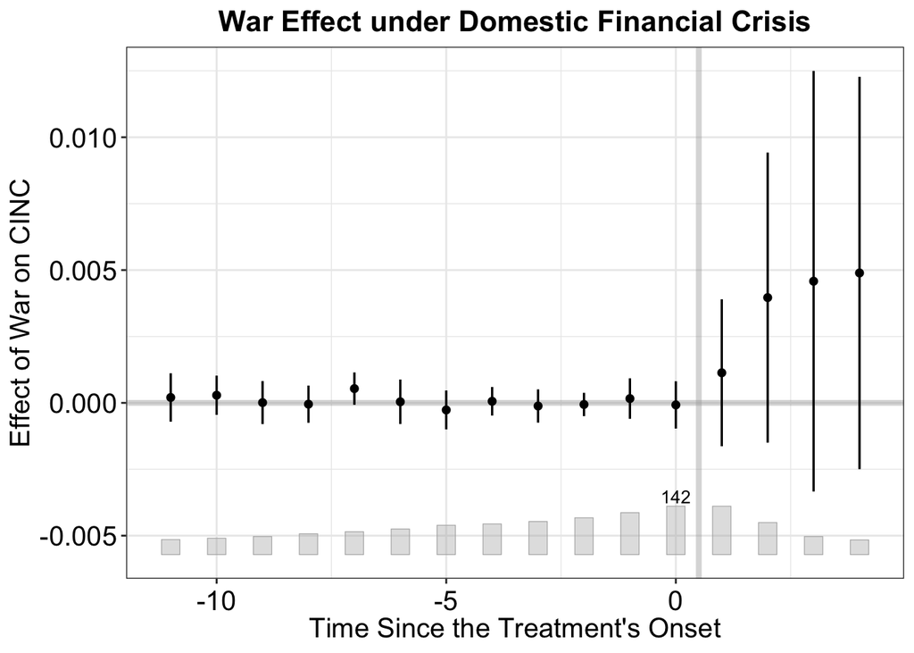

```r
plot(ife_cinc_dom_economy_1, main = "War Effect under Domestic Financial Crisis", ylab = "Effect of War on CINC")
```

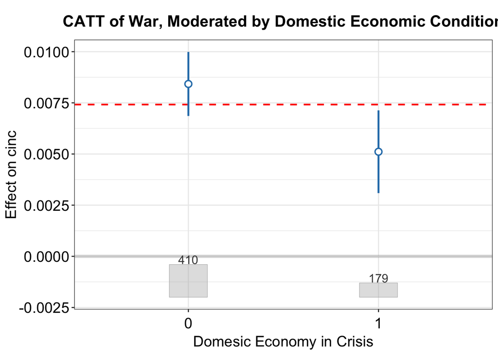

```r
plot(ife_cinc_dom_economy_1, type = "hte", covariate="any_crisis", xlab = "Domesic Economy in Crisis", main = "CATT of War, Moderated by Domestic Economic Condition")
```

[figure not shown]

```r
plot(ife_cinc_dom_economy_2, main = "War Effect under Domestic Financial Crisis", ylab = "Effect of War on CINC, Controlled for Military Characteristics", ylim = c(-10,5))
```

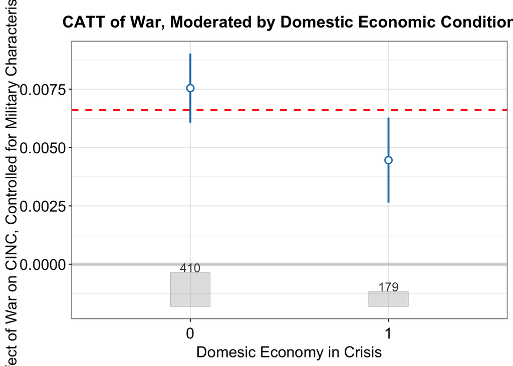

```r
plot(ife_cinc_dom_economy_2, type = "hte", covariate="any_crisis", xlab = "Domesic Economy in Crisis", ylab = "Effect of War on CINC, Controlled for Military Characteristics", main = "CATT of War, Moderated by Domestic Economic Condition")
```

### External

```r
ife_cinc_ex_economy_1 <- fect(cinc ~ at_war + flag_GCD + tpop, data = merged_use_panel,
               index = c("iso3","year"), force = "two-way", method = "ife", r = c(0,5),
               se = TRUE, cores = 8, nboots = 10, parallel = TRUE)
```

```
## For identification purposes, units whose number of untreated periods <5 are dropped automatically.
```

```
## Parallel computing ...
```

```
## Cross-validating ...
```

```
## Criterion: Mean Squared Prediction Error
```

```
## Interactive fixed effects model...
```

```
## r = 0; sigma2 = 0.00020; IC = -8.04898; PC = 0.00019; MSPE = 0.00023
```

```
## r = 1; sigma2 = 0.00001; IC = -10.40339; PC = 0.00001; MSPE = 0.00002
```

```
## r = 2; sigma2 = 0.00001; IC = -10.41101; PC = 0.00001; MSPE = 0.00008
```

```
## r = 3; sigma2 = 0.00001; IC = -10.34631; PC = 0.00001; MSPE = 0.00013
```

```
## r = 4; sigma2 = 0.00000; IC = -10.40063; PC = 0.00001; MSPE = 0.00012
```

```
## r = 5; sigma2 = 0.00000; IC = -10.20399; PC = 0.00000; MSPE = 0.00016
```

```
##
##  r* = 1
```

```
## F-test Failed. The estimated covariance matrix is singular.
```

```r
ife_cinc_ex_economy_2 <- fect(cinc ~ at_war + flag_GCD + tpop + milex + milper, data = merged_use_panel,
               index = c("iso3","year"), force = "two-way", method = "ife", r = c(0,5),
               se = TRUE, cores = 8, nboots = 10, parallel = TRUE)
```

```
## For identification purposes, units whose number of untreated periods <5 are dropped automatically.
```

```
## Parallel computing ...
```

```
## Cross-validating ...
```

```
## Criterion: Mean Squared Prediction Error
```

```
## Interactive fixed effects model...
```

```
## r = 0; sigma2 = 0.00020; IC = -8.07171; PC = 0.00018; MSPE = 0.00023
```

```
## r = 1; sigma2 = 0.00001; IC = -10.46989; PC = 0.00001; MSPE = 0.00003
```

```
## r = 2; sigma2 = 0.00001; IC = -10.48822; PC = 0.00001; MSPE = 0.00003
```

```
## r = 3; sigma2 = 0.00001; IC = -10.20741; PC = 0.00001; MSPE = 0.00008
```

```
## r = 4; sigma2 = 0.00000; IC = -10.18653; PC = 0.00001; MSPE = 0.00010
```

```
## r = 5; sigma2 = 0.00000; IC = -9.86127; PC = 0.00001; MSPE = 0.00015
```

```
##
##  r* = 2
```

```
## F-test Failed. The estimated covariance matrix is singular.
```

## Point Estimates Comparison

## TWFE

### Effect of war on CINC

```r
# war_dom = at war when the state was experiencing economic crisis
merged_use_panel <- merged_use_panel %>%
  mutate(war_dom = as.numeric(at_war == 1 & any_crisis == 1), 1, 0)
```

```r
merged_use_panel <- merged_use_panel %>%
  mutate(war_ex = as.numeric(at_war == 1 & flag_GCD == 1), 1, 0)
```

```r
table(merged_use_panel$war_dom)
```

```
##
##    0    1
## 2911  179
```

```r
table(merged_use_panel$war_ex)
```

```
##
##    0    1
## 2980  110
```

```r
## Cannot control for  milex + milper due to limited observations. VCOV matrix is not positive semi-definite once milex + milper are added.
twfe_war <- feols(cinc ~ at_war + tpop + milex + milper| iso3 + year, cluster = ~iso3, data = merged_use_panel)
twfe_interstate <- feols(cinc ~ is_inter + tpop + milex + milper| iso3 + year, cluster = ~iso3, data = merged_use_panel)
twfe_homeland <- feols(cinc ~ homeland + tpop + milex + milper| iso3 + year, cluster = ~iso3, data = merged_use_panel)
# Looking at war foght when domestic economy is in crisis
twfe_war_dom <- feols(cinc ~ war_dom + tpop + milex + milper| iso3 + year, cluster = ~iso3, data = merged_use_panel)
# Looking at war foght when external credit constraints
twfe_war_ex <- feols(cinc ~ war_ex + tpop + milex + milper| iso3 + year, cluster = ~iso3, data = merged_use_panel)
ci_wars   <- grab_ci(twfe_war, "at_war")
ci_inter   <- grab_ci(twfe_interstate, "is_inter")
ci_homeland   <- grab_ci(twfe_homeland, "homeland")
ci_war_dom  <- grab_ci(twfe_war_dom, "war_dom")
ci_war_ex  <- grab_ci(twfe_war_ex, "war_ex")

# Create the combined data frame with explicit ordering
ci_all <- bind_rows(ci_wars, ci_inter, ci_homeland, ci_war_dom, ci_war_ex) %>%
  mutate(
    pretty_name = case_when(
      variable == "at_war"       ~ "Any War Types",
      variable == "is_inter"     ~ "Interstate War",
      variable == "homeland"     ~ "War on National Territory",
      variable == "war_dom"      ~ "War | Domestic Economic Crisis",
      variable == "war_ex"       ~ "War | External Credit Constraint"
    ),
    # Create an ordering variable to preserve the desired sequence
    order_var = case_when(
      variable == "at_war"       ~ 1,
      variable == "is_inter"     ~ 2,
      variable == "homeland"     ~ 3,
      variable == "war_dom"      ~ 4,
      variable == "war_ex"       ~ 5
    )
  ) %>%
  arrange(order_var)  # Sort by the ordering variable

df_tw <- ci_all %>%
  transmute(
    panel = "Effect of War on Short-term State Capacity (Panel)",
    x_lab = as.character(pretty_name),
    estimate, lb, ub
  )

# Convert x_lab to factor with levels in the correct order
df_tw$x_lab <- factor(df_tw$x_lab, levels = unique(df_tw$x_lab))

p_tw <- make_panel_single(
  df_tw,
  facet_title = "TWFE Regression of War on State Capacity",
  ylab = "Effect on CINC, 95% Confidence Interval",
  ylim_all = c(-0.025, 0.025),
  show_ylim = TRUE
)
```

```r
ggsave(
  filename = "/Users/joey/Library/CloudStorage/Dropbox/WS/output/graphs/twfe_coefs/panel_twfe.pdf",
  plot     = p_tw,
  width = 15, height = 5
)
ggsave(
  filename = "/Users/joey/Library/CloudStorage/Dropbox/WS/output/graphs/twfe_coefs/panel_twfe.png",
  plot     = p_tw,
  width = 15, height = 5
)
```

```r
models <- list(
  "Any War" = twfe_war,
  "Interstate War" = twfe_interstate,
  "War | Homeland" = twfe_homeland,
  "War | Domestic Crisis" = twfe_war_dom,
  "War | External Constraints" = twfe_war_ex
)
# Basic summary table
modelsummary(models, stars = TRUE)
```

|  | Any War | Interstate War | War \| Homeland | War \| Domestic Crisis | War \| External Constraints |
| --- | --- | --- | --- | --- | --- |
| at_war | 0.008* |  |  |  |  |
|  | (0.004) |  |  |  |  |
| tpop | 0.000 | 0.000 | 0.000 | 0.000 | 0.000 |
|  | (0.000) | (0.000) | (0.000) | (0.000) | (0.000) |
| milex | -0.000 | -0.000 | -0.000 | -0.000 | -0.000 |
|  | (0.000) | (0.000) | (0.000) | (0.000) | (0.000) |
| milper | 0.000 | 0.000 | 0.000 | 0.000 | 0.000 |
|  | (0.000) | (0.000) | (0.000) | (0.000) | (0.000) |
| is_inter |  | 0.010* |  |  |  |
|  |  | (0.004) |  |  |  |
| homeland |  |  | 0.006+ |  |  |
|  |  |  | (0.003) |  |  |
| war_dom |  |  |  | 0.006 |  |
|  |  |  |  | (0.004) |  |
| war_ex |  |  |  |  | 0.010* |
|  |  |  |  |  | (0.004) |
| Num.Obs. | 3090 | 3090 | 3090 | 3090 | 3090 |
| R2 | 0.903 | 0.903 | 0.901 | 0.901 | 0.901 |
| R2 Adj. | 0.898 | 0.898 | 0.896 | 0.896 | 0.896 |
| R2 Within | 0.065 | 0.065 | 0.052 | 0.052 | 0.053 |
| R2 Within Adj. | 0.064 | 0.064 | 0.051 | 0.050 | 0.052 |
| AIC | -15672.4 | -15671.7 | -15630.1 | -15628.5 | -15633.4 |
| BIC | -14761.0 | -14760.3 | -14718.7 | -14717.1 | -14722.0 |
| RMSE | 0.02 | 0.02 | 0.02 | 0.02 | 0.02 |
| Std.Errors | by: iso3 | by: iso3 | by: iso3 | by: iso3 | by: iso3 |
| FE: iso3 | X | X | X | X | X |
| FE: year | X | X | X | X | X |

+ p < 0.1, * p < 0.05, ** p < 0.01, *** p < 0.001

# Does external credit condition shapes how a war is financed?

```r
make_panel_single <- function(df, facet_title,
                              ylab = NULL, xlab = NULL,
                              ylim_all = NULL,
                              show_ylim = TRUE) {
  df <- df %>% mutate(type = facet_title)

  # Reorder x_lab by string length (shortest to longest)
  df <- df %>%
    mutate(x_lab = fct_reorder(x_lab, str_length(x_lab)))

  p <- ggplot(df, aes(x = x_lab, y = estimate,
                      colour = ifelse(lb < 0 & ub > 0, "red", "black"))) +
    geom_hline(yintercept = 0, linetype = "dashed",
               colour = "grey60", linewidth = 0.9) +
    geom_errorbar(aes(ymin = lb, ymax = ub),
                  width = 0.2, linewidth = 0.9, show.legend = FALSE) +
    geom_point(size = 2) +
    scale_colour_identity() +
    facet_wrap(~type) +
    labs(x = xlab, y = ylab) +
    theme_bw() +
    theme(
      strip.background = element_rect(fill = "grey90", colour = "black"),
      strip.text       = element_text(size = 11, face = "bold"),
      axis.text.x      = element_text(size = 10,  hjust = 0.5),
      axis.title.x     = element_text(size = 11),
      axis.title.y     = element_text(size = 12)
    )

  # ✅ Apply y-limits if provided
  if (show_ylim && !is.null(ylim_all)) {
    p <- p + coord_cartesian(ylim = ylim_all)
    # Or use: p <- p + lims(y = ylim_all)
  }

  return(p)
}
```

```r
ccwp <- read.csv("../data/CCWP/CCWP-Data.csv")
```

`wtax` | War Tax: tax revenues specifically earmarked for the war effort. |  
`domtax` | Domestic Taxation: share of war paid for out of domestic tax revenues. |  
`domwf` | Domestic War Finance: all domestic revenues including taxation, existing coffers, domestic borrowing, and printing money. |  
`mnyabrd` | External Funding: war financed by sources from abroad, including plunder, grants, loans, or aid. |  
`totalbrw` | Total Borrow: total amount borrowed to finance war, both domestic and foreign. |

```r
uk_banking_crisis <- c(1825, 1837, 1847, 1857, 1866, 1890, 1816, 1817, 1826, 1838, 1839, 1848, 1878)
uk_financial_crisis <- c(1816, 1817, 1825, 1826, 1837, 1838, 1839, 1847, 1848, 1857, 1858, 1866, 1878, 1879, 1880, 1890, 1908)

# Function to count overlap
count_overlap <- function(start, end, crisis_years) {
  sum(crisis_years >= start & crisis_years <= end, na.rm = TRUE)
}

# Apply to ccwp
ccwp_war_1 <- ccwp %>%
  filter (yrbeg1 >= 1816, yrend1 <= 1913)%>%
  mutate(
    duration = yrend1 - yrbeg1 + 1,
    yr_bk_crisis = mapply(count_overlap, yrbeg1, yrend1, MoreArgs = list(crisis_years = uk_banking_crisis)),
    yr_crisis    = mapply(count_overlap, yrbeg1, yrend1, MoreArgs = list(crisis_years = uk_financial_crisis))
  )
```

```r
lin_wtax_rr     <- feols(wtax     ~ yr_bk_crisis  + duration | stateabb, data = ccwp_war_1, cluster = "stateabb")
```

```
## NOTES: 14 observations removed because of NA values (LHS: 14).
##        9 fixed-effect singletons were removed (9 observations).
```

```r
lin_wtax_gcd    <- feols(wtax     ~ yr_crisis + duration | stateabb,    data = ccwp_war_1, cluster = "stateabb")
```

```
## NOTES: 14 observations removed because of NA values (LHS: 14).
##        9 fixed-effect singletons were removed (9 observations).
```

```r
lin_domtax_rr   <- feols(domtax   ~ yr_bk_crisis + duration | stateabb, data = ccwp_war_1, cluster = "stateabb")  # FIXED
```

```
## NOTES: 11 observations removed because of NA values (LHS: 11).
##        9 fixed-effect singletons were removed (9 observations).
```

```r
lin_domtax_gcd  <- feols(domtax   ~ yr_crisis + duration | stateabb,    data = ccwp_war_1, cluster = "stateabb")
```

```
## NOTES: 11 observations removed because of NA values (LHS: 11).
##        9 fixed-effect singletons were removed (9 observations).
```

```r
lin_domwf_rr    <- feols(domwf    ~ yr_bk_crisis + duration| stateabb, data = ccwp_war_1, cluster = "stateabb")
```

```
## NOTES: 9 observations removed because of NA values (LHS: 9).
##        7 fixed-effect singletons were removed (7 observations).
```

```r
lin_domwf_gcd   <- feols(domwf    ~ yr_crisis + duration| stateabb,    data = ccwp_war_1, cluster = "stateabb")
```

```
## NOTES: 9 observations removed because of NA values (LHS: 9).
##        7 fixed-effect singletons were removed (7 observations).
```

```r
lin_mnyabrd_rr  <- feols(mnyabrd  ~ yr_bk_crisis + duration| stateabb, data = ccwp_war_1, cluster = "stateabb")
```

```
## NOTES: 8 observations removed because of NA values (LHS: 8).
##        8 fixed-effect singletons were removed (8 observations).
```

```r
lin_mnyabrd_gcd <- feols(mnyabrd  ~ yr_crisis + duration| stateabb,    data = ccwp_war_1, cluster = "stateabb")
```

```
## NOTES: 8 observations removed because of NA values (LHS: 8).
##        8 fixed-effect singletons were removed (8 observations).
```

```r
lin_totalbrw_rr <- feols(totalbrw ~ yr_bk_crisis + duration| stateabb, data = ccwp_war_1, cluster = "stateabb")
```

```
## NOTES: 11 observations removed because of NA values (LHS: 11).
##        9 fixed-effect singletons were removed (9 observations).
```

```r
lin_totalbrw_gcd<- feols(totalbrw ~ yr_crisis + duration| stateabb,    data = ccwp_war_1, cluster = "stateabb")
```

```
## NOTES: 11 observations removed because of NA values (LHS: 11).
##        9 fixed-effect singletons were removed (9 observations).
```

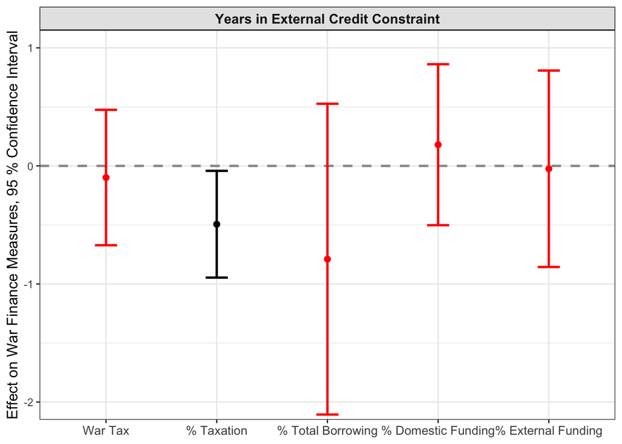

```r
ci_gcd1   <- grab_ci(lin_wtax_gcd, "yr_crisis")
ci_gcd2  <- grab_ci(lin_domtax_gcd, "yr_crisis")
ci_gcd3  <- grab_ci(lin_domwf_gcd, "yr_crisis")
ci_gcd4  <- grab_ci(lin_mnyabrd_gcd, "yr_crisis")
ci_gcd5  <- grab_ci(lin_totalbrw_gcd, "yr_crisis")

# Create the combined data frame with explicit ordering
ci_gcd <- bind_rows(ci_gcd1, ci_gcd2, ci_gcd3, ci_gcd4, ci_gcd5)

x_order <- c("War Tax",
             "% Taxation",
             "% Domestic Funding",
             "% External Funding",
             "% Total Borrowing")

df_war_fi <- ci_gcd %>%
  mutate(
    panel = "Effect of External Credit Constraint",
    x_lab = factor(x_order)    # assign fixed order
  ) %>%
  select(panel, x_lab, estimate, lb, ub)

p_war_gcd <- make_panel_single(
  df_war_fi,
   facet_title = "Years in External Credit Constraint",
  ylim_all = c(-2, 1),
  ylab ="Effect on War Finance Measures, 95 % Confidence Interval",
  show_ylim = TRUE
)
p_war_gcd
```

**Appendix -RR crisis**

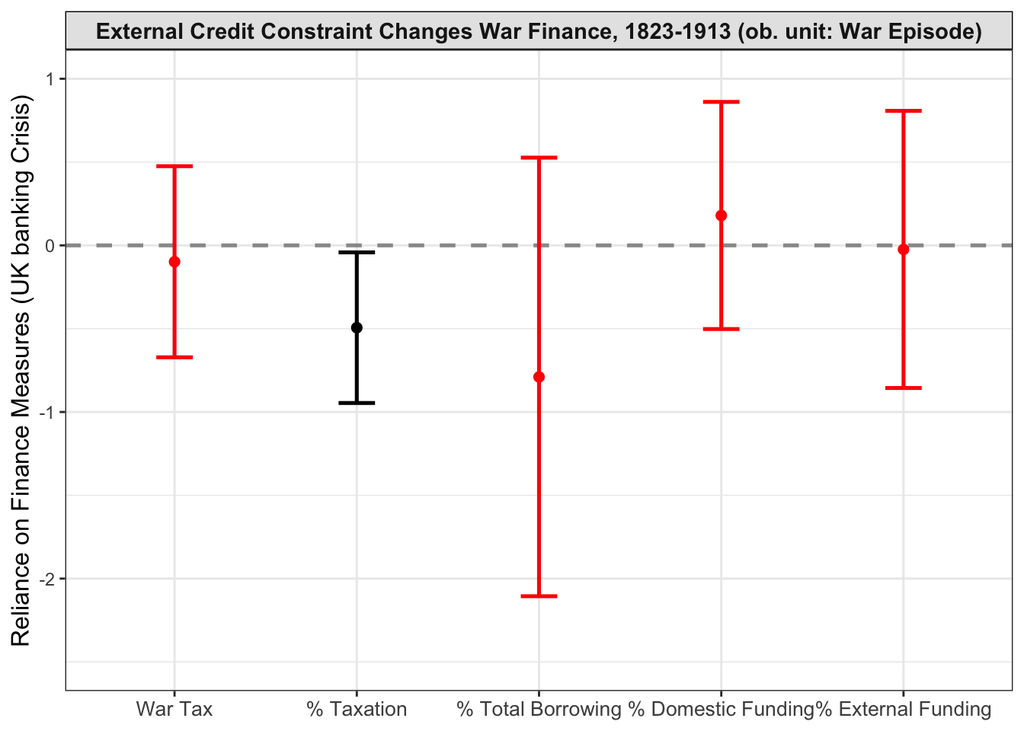

```r
ci_rr1   <- grab_ci(lin_wtax_rr, "yr_bk_crisis")
ci_rr2  <- grab_ci(lin_domtax_rr, "yr_bk_crisis")
ci_rr3  <- grab_ci(lin_domwf_rr, "yr_bk_crisis")
ci_rr4  <- grab_ci(lin_mnyabrd_rr, "yr_bk_crisis")
ci_rr5  <- grab_ci(lin_totalbrw_rr, "yr_bk_crisis")

# Create the combined data frame with explicit ordering
ci_rr <- bind_rows(ci_rr1, ci_rr2, ci_rr3, ci_rr4, ci_rr5)

df_war_fi_rr <- ci_rr %>%
  mutate(
    panel = "Year in UK Banking Crisis",
    x_lab = x_order  # assign fixed order
  ) %>%
  select(panel, x_lab, estimate, lb, ub)

p_war_fi_rr <- make_panel_single(
  df_war_fi_rr,
  facet_title = "External Credit Constraint Changes War Finance, 1823-1913 (ob. unit: War Episode)",
  ylab = "Reliance on Finance Measures (UK banking Crisis)",
  ylim_all = c(-2.5, 1),
  show_ylim = TRUE
)
p_war_fi_rr
```